# Introduction to Statistical Learning

# Lab 1: Introduction to R

## Basic commands

```r
# creating a vector of numbers
x = c(1, 2, 3, 4)

# a sequence of number
z = seq(1, 10)

# we can also add step
z = seq(-pi, pi, length=50)

# printing
print(z)
```

```
 [1] -3.14159265 -3.01336438 -2.88513611 -2.75690784 -2.62867957 -2.50045130 -2.37222302
 [8] -2.24399475 -2.11576648 -1.98753821 -1.85930994 -1.73108167 -1.60285339 -1.47462512
[15] -1.34639685 -1.21816858 -1.08994031 -0.96171204 -0.83348377 -0.70525549 -0.57702722
[22] -0.44879895 -0.32057068 -0.19234241 -0.06411414  0.06411414  0.19234241  0.32057068
[29]  0.44879895  0.57702722  0.70525549  0.83348377  0.96171204  1.08994031  1.21816858
[36]  1.34639685  1.47462512  1.60285339  1.73108167  1.85930994  1.98753821  2.11576648
[43]  2.24399475  2.37222302  2.50045130  2.62867957  2.75690784  2.88513611  3.01336438
[50]  3.14159265
```

```r
print(x)
```

```
[1] 1 2 3 4
```

```r
# accessing the value of x[i]
# index starts at 1 not like python
y = x[1]
print(y)
```

```
[1] 1
```

```r
# length of the vector
len = length(x)
cat("The length of x is: ", len)
```

```
The length of x is:  4
```

```r
# basic operations
x = 3
y = 5

# addition
print(x + y)
```

```
[1] 8
```

```r
# substraction
print(x - y)
```

```
[1] -2
```

```r
# multiplication
print(x * y)
```

```
[1] 15
```

```r
# division
print(x / y)
```

```
[1] 0.6
```

```r
# power
print(x^2)
```

```
[1] 9
```

```r
# listing all saved objects
list_ob = ls()
print(list_ob)
```

[output not shown]

```r
# to delete all stored objects
rm(list = ls())

# if we try to call x an erro will occur
#print(x)

# if we want to use a function be we don't know how to use it exactly
?matrix

# let's create one
mat = matrix(data = c(1, 2, 3, 4), nrow = 2, ncol = 2, byrow = TRUE)
print(mat)
```

```
     [,1] [,2]
[1,]    1    2
[2,]    3    4
```

```r
# we can access the elements through indexation
print(mat[1,1])
```

```
[1] 1
```

```r
print(mat[1,])
```

```
[1] 1 2
```

```r
print(mat[,2])
```

```
[1] 2 4
```

```r
# we can also generate random vectors
# normal distribution
rand_vec = rnorm(10)
print(rand_vec)
```

```
 [1]  1.0011132  0.7474520 -0.6265748  0.3952237 -0.8921680  0.6308184 -0.4327052  0.4521386
 [9]  0.3679990 -0.2703875
```

```r
# see also, pnorm, qnorm, dbnorm
# https://www.stat.umn.edu/geyer/old/5101/rlook.html#:~:text=rnorm%20is%20the%20R%20function,standard%20deviation%20of%20the%20distribution.

# for the sake of reproducibility, we can fix a seed
set.seed(42)
x = rnorm(n = 20, mean = 0, sd=1)
y = 7 + 2*x

# variance, correlation, mean, standard deviation
print(var(x))
```

```
[1] 1.722993
```

```r
print(mean(x))
```

```
[1] 0.19192
```

```r
print(sd(y))
```

```
[1] 2.625257
```

```r
print(cor(x, y))
```

```
[1] 1
```

## Plotting graphics

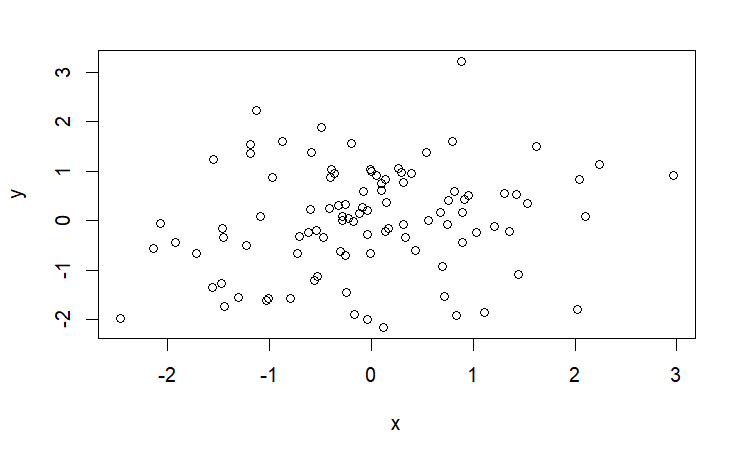

```r
# simplest way to plot a graphic
x = rnorm(100)
y = rnorm(100)
# scatter plot
plot(x, y)
```

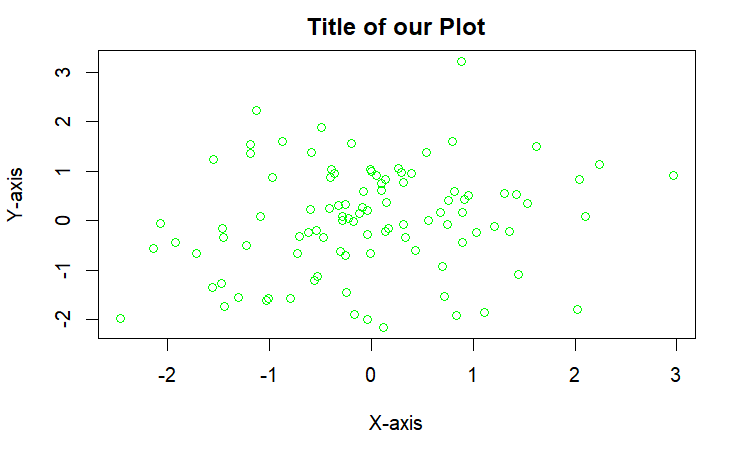

```r
# we can make it better by adding a title and labels
plot(x, y, xlab="X-axis",
     ylab="Y-axis",
     col="green",
     main="Title of our Plot")
```

```r
# these plots can also be saved
# as pdf
pdf("../plots/first_plot.pdf")
plot(x, y, xlab="X-axis",
     ylab="Y-axis",
     col="green",
     main="Title of our Plot")
# then, we tell R that we are done
dev.off()
```

```r
# we can also save it as a jpeg, png
png("../plots/second_plot.png")
```

```r
plot(x, y, xlab="X-axis",
     ylab="Y-axis",
     col="red",
     main="Title of our Plot")
# then, we tell R that we are done
dev.off()
```

## More sophisticated plots

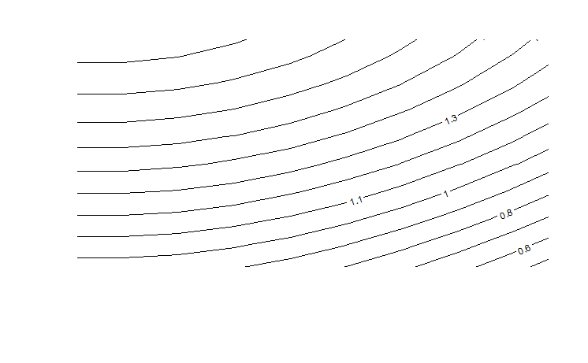

```r
# contours
# we use it for 3D data as a topolgical map
# x, y should be in increasing order
x = seq(-pi, pi, length = 50)
y = x
f = outer(x, y, function(x, y) cos(x) + sin(y))
plot.new()
contour(x, y, f, nlevels = 45, add = T)
```

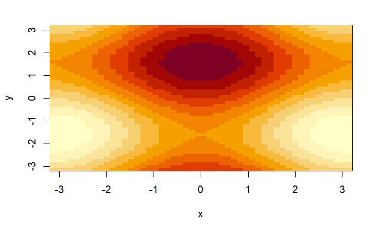

```r
# with a color map
image(x, y, f)
```

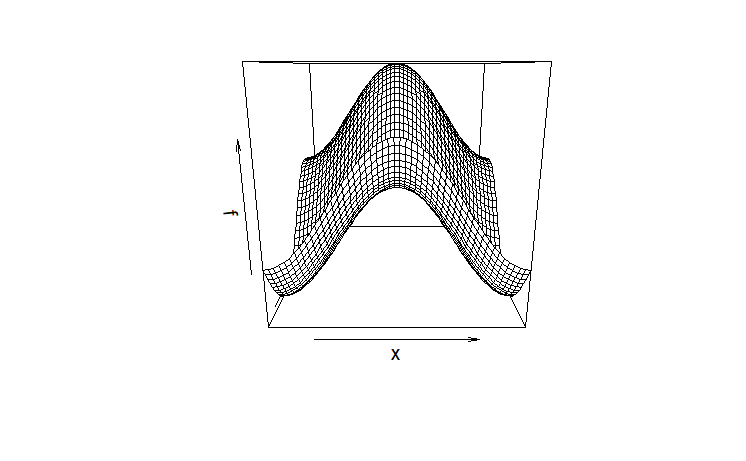

```r
# or 3D
persp(x, y, f)
```

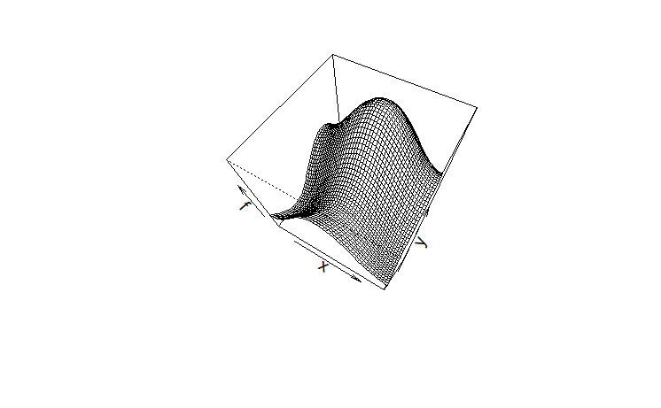

```r
# we can change the angle of view

persp(x, y, f,
      theta = 30,
      phi = 60)
```

## Loading data

```r
# we use the function read.table()
auto = read.table("../datasets/Auto.data")

# we can view it
View(auto)

# see the first rows
head(auto)
```

|  | V1 | V2 | V3 | V4 | V5 | V6 | V7 | V8 | V9 |
| --- | --- | --- | --- | --- | --- | --- | --- | --- | --- |
| 1 | mpg | cylinders | displacement | horsepower | weight | acceleration | year | origin | name |
| 2 | 18.0 | 8 | 307.0 | 130.0 | 3504. | 12.0 | 70 | 1 | chevrolet chevelle malibu |
| 3 | 15.0 | 8 | 350.0 | 165.0 | 3693. | 11.5 | 70 | 1 | buick skylark 320 |
| 4 | 18.0 | 8 | 318.0 | 150.0 | 3436. | 11.0 | 70 | 1 | plymouth satellite |
| 5 | 16.0 | 8 | 304.0 | 150.0 | 3433. | 12.0 | 70 | 1 | amc rebel sst |
| 6 | 17.0 | 8 | 302.0 | 140.0 | 3449. | 10.5 | 70 | 1 | ford torino |

Sometimes, `R` may assume that the variable names are part of the data, thus we need to tell him that the first line is actually the header

```r
# header = T (or TRUE)
Auto = read.table("../datasets/Auto.data",
                  header = T,
                  na.strings = "?",
                  stringsAsFactors = T)
```

The `na.strings` tells `R` that the variables containing the sign `?` represent a missing element, as for `stringsAsFactors` , it tells `R` to consider variables filled with characters as **qualitative** variables.

We can also use the `csv` format datasets.

```r
# saving in csv format
write.csv(Auto, "../datasets/auto.csv")
```

```r
# reloading
auto = read.csv("../datasets/auto.csv",
                header = T,
                  na.strings = "?",
                  stringsAsFactors = T)
View(auto)

# dimension of our dataset
print(dim(auto))
```

```
[1] 397  10
```

We can also check names of our variables.

```r
names(auto)
```

```
 [1] "X"            "mpg"          "cylinders"    "displacement" "horsepower"   "weight"
 [7] "acceleration" "year"         "origin"       "name"
```

And, perhaps we will need to delete rows containing missing data.

```r
# no missing data
auto = na.omit(auto)
print(dim(auto))
```

```
[1] 397  10
```

## Additional Graphical and Numerical Summaries

We may want to plot some of the variables in our data set, but `R` can’t access them.

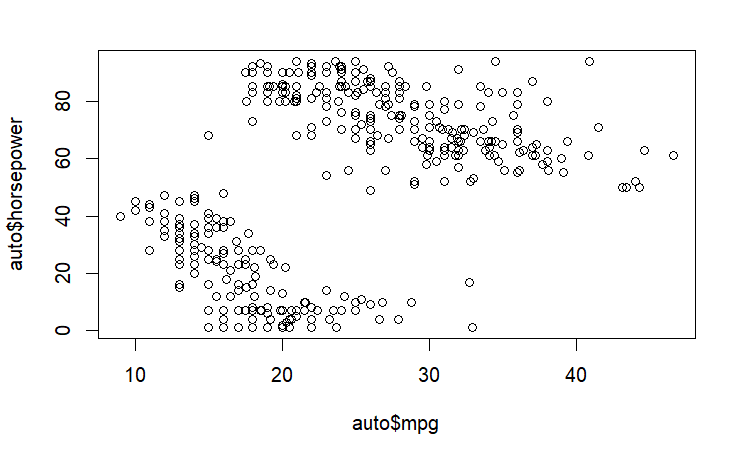

```r
# first solution
plot(auto$mpg, auto$horsepower)
```

```r
# second solution
attach(auto)
plot(cylinders, mpg)
```

[output not shown]

```r
# convert
cylinders = as.factor(cylinders)

#plot
plot(cylinders, mpg)
```

[output not shown]

We can also plot histograms:

```r
hist(mpg,
     col='red')
# we can change number of breaks
hist(mpg,
     col = 5,
     breaks = 15)
```

[output not shown]

If we want some fast representation of all the scatter plots, then we can use the function called `pairs`.

```r
pairs(auto)
# to identify the value of a variable in a scatter plot for a pair
plot(horsepower, mpg)
identify(horsepower, mpg, cylinders)
```

[output not shown]

Finally, we may want to have a summary for all the central tendency and position stats for all variables

```r
summary(auto)
```

[output not shown]